# Exercises STAT340 - Regression analysis - part I

# 3 Data set `birth`

Load the data set `birth` that we inspected in week 1. This contains 189 birth weights from Massachusetts, USA, and some additional variables. See the week 1 exercise for more details.

## 3.1 Effect of mothers weight

In week 1 we plotted the birth weights of the children against the weights of their mothers, and added some *trend line* to the plot. This indicated that heavier mothers gave birth to heavier children. We will now make a formal test of this.

Fit a simple linear regression model with `BWT` as response and `LWT` as predictor. Test if there is a significant effect of mothers weight (`LWT`) on birth weight (`BWT`) with a 5% rejection level and then at a 1% rejection level

- What are the hypothesis you are testing?
- What is your conclusion on the effect of mothers weight on birth weight?
- Find the $R^2$. Would you say the model fits the data well?

**Solution**

we fit the model by

```r
library(BIAS.data)
data(birth)

lm.obj <- lm(BWT~LWT, data = birth)
```

We want to test the hypotheses
$$H_0:
\beta_1 = 0 \;\;\;\mbox{ versus }\;\;\; H_1: \beta_0 \neq 0$$
We do the actual testing by the `summary()` function:

```r
summary(lm.obj)
```

```
##
## Call:
## lm(formula = BWT ~ LWT, data = birth)
##
## Residuals:
##      Min       1Q   Median       3Q      Max
## -2192.18  -503.63    -3.91   508.25  2075.53
##
## Coefficients:
##             Estimate Std. Error t value Pr(>|t|)
## (Intercept) 2369.672    228.431  10.374   <2e-16 ***
## LWT            4.429      1.713   2.586   0.0105 *
## ---
## Signif. codes:  0 '***' 0.001 '**' 0.01 '*' 0.05 '.' 0.1 ' ' 1
##
## Residual standard error: 718.2 on 187 degrees of freedom
## Multiple R-squared:  0.03452,    Adjusted R-squared:  0.02935
## F-statistic: 6.686 on 1 and 187 DF,  p-value: 0.01048
```

From the output we see that the coefficient for `LWT` ($\beta_1$) is estimated to `4.429`, and the corresponding t-statistic is `2.586`. This gives a p-value of `0.0105`. This p-value is below 0.05, but not below 0.01. We claim that there is an effect of mothers weight on birth weight at the 5% significance level, but not at the 1% level.

The $R^2$ is very low at only `0.03452`, indicating the model has a poor fit to the data. The slope $\beta_1$ is estimated to `4.429`. This means an increase in `LWT` of 1 pound (`LWT` is measured in pounds) gives an average increase in birth weight of `4.429`grams (`BWT` is measured in grams). Thus, even if the effect is significant (at 5%), the effect is not very big, i.e. the slope is not very steep, and the $R^2$ remains small. The total variation in birth weight must be due to many other predictors than the mothers weight.

## 3.2 Scatter-plot

Make a scatter plot of `LWT` vs `BWT`. Add the regression line to the plot. Add proper texts on the axes.

How can we see from this plot the $R^2$ must be rather low in this case?

**Solution**

```r
library(tidyverse)
```

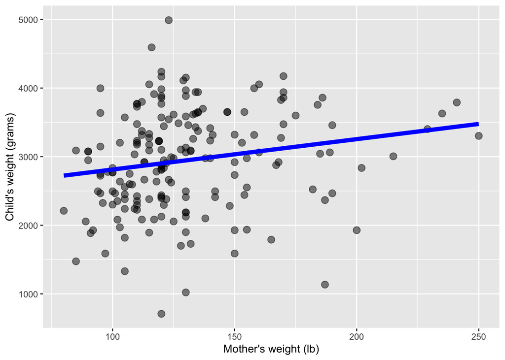

```r
lm.obj$model %>%
  mutate(Fitted = lm.obj$fitted.values) %>%
  ggplot() +
  geom_point(aes(x = LWT, y = BWT), size = 3, alpha = 0.5) +
  geom_line(aes(x = LWT, y = Fitted), color = "blue1", linewidth = 2) +
  labs(x = "Mother's weight (lb)", y = "Child's weight (grams)")
```

We can see why the R-squared is low. It is computed by
$$R^2 = 1 - \frac{SSE}{SSY}$$
The $SSE$ is simply the sum of the squared distance from each point down/up to the blue regression line.

The $SSY$ is simply the sum of the squared distance from each point down/up to an imaginary line that *lies flat* at the mean y-value.

In this case this imaginary line would be very similar to the blue regression line, since the latter has such a small slope. Thus, $SSE$ and $SSY$ becomes almost equal, and from the formula this means a very low $R^2$. To get a large $R^2$ the slope must be steeper.

## 3.3 Confidence Intervals

Find a 95% confidence interval for the slope in the fitted model from above. Also find the 99% confidence interval Comment on the intervals in light of the hypothesis test

**Solution**

```r
confint(lm.obj, level = 0.95)
```

```
##                   2.5 %    97.5 %
## (Intercept) 1919.039836 2820.3043
## LWT            1.049927    7.8086
```

```r
confint(lm.obj, level = 0.99)
```

```
##                     0.5 %      99.5 %
## (Intercept) 1775.20974036 2964.134385
## LWT           -0.02866992    8.887197
```

The 95% confidence interval for the slope does *not* cover 0, as we expect since we rejected the null hypothesis at 5% level.

The 99% interval covers 0, also as expected, since we could not reject the null hypothesis at the 1% level.

Note: The value 0 we focus on here is because a slope with value 0 means we have no effect. It is the same as in the null hypothesis $H_0:\beta = 0$. If the null hypothesis, for some reason, was $H_0:\beta = 1$, then we would consider if the confidence intervals overlap the value 1.

## 3.4 Subsets

An element of randomness in our data lies in the fact that we have sampled a (random) subset from the entire population of all data cases we could have considered. To illustrate this, and to visualize this randomness, let us simulate this subsetting again on the current data set!

In the `birth` data set we have 189 data cases. How would the picture look like if we had only 50 data cases? Make R code to do as follows:

- We want to fit our model to data sets of size `sub.size <- 50`
- Select randomly this many rows from the data set. You may use this code: `birth.sub <- slice(birth, sample(1:nrow(birth), sub.size))`
- Fit the same model as above, but use the data subset
- Collect from the fitted model
  - the data used when fitting the model (`lm.obj$model`)
  - the fitted values (`lm.obj$fitted.values`)
  - the estimated slope (`lm.obj$coefficients[2]`)
- Put these results into a table named `res.tbl`, with columns `BWT`, `LWT`, `Fitted` and `Slope` (same value in all rows).

Next, repeat this 1000 times, and collect the same results as above each time. In addition, the resulting table from above should also have another column named `Subset` indicating which rows are from the same data subset. Here is a code skeleton:

```r
library(tidyverse)
# define N.sub and sub-size here
result.tbl <- NULL   # empty table
for(i in ___){
  # sub-set the birth data
  # fit model
  # collect results into res.tbl
  result.tbl <- res.tbl %>%
    mutate(Subset = i) %>%
    bind_rows(result.tbl)   # add new rows to the result.tbl
}
```

Make a histogram of the estimated slopes. How is this related to the p-value and confidence interval we would get for the slope?

Make a scatter-plot of the data used in the subsets (`BWT` versus `LWT` as before), and add the fitted regression lines and color them red. To get one line for each subset, use the `group = Subset` aesthetic in `geom_line()`.

When we fit a model to 1 data set, we get 1 estimate of slope and 1 regression line. From the plots above you should now have a more correct image: The estimates have an element of randomness, the values we get are just randomly sampled from a range of values. Remember these pictures.

**Solution**

Here is one way of implementing it:

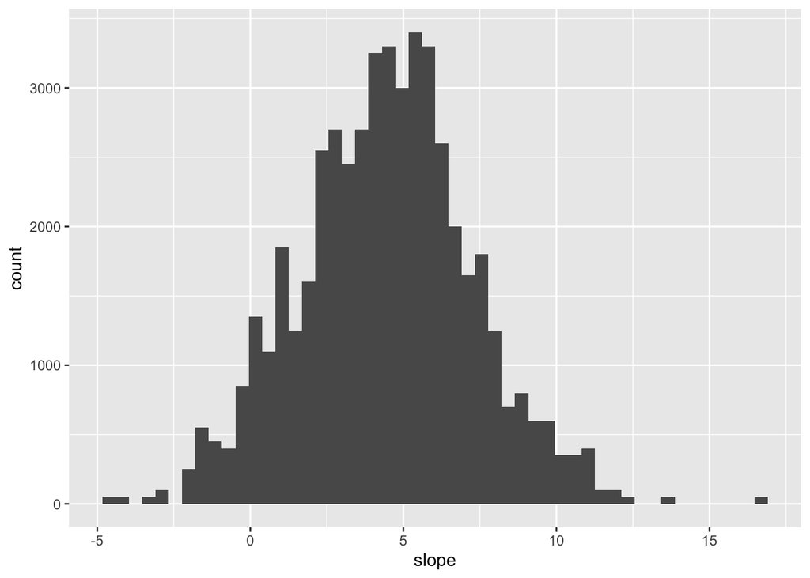

```r
library(tidyverse)
N.sub <- 1000
sub.size <- 50
result.tbl <- NULL
for(i in 1:N.sub){
  birth.sub <- slice(birth, sample(1:nrow(birth), sub.size))
  lm.obj <- lm(BWT~LWT, data = birth.sub)
  res.tbl <- lm.obj$model %>%
    mutate(Fitted = lm.obj$fitted.values) %>%
    mutate(slope = lm.obj$coefficients[2])
  result.tbl <- res.tbl %>%
    mutate(Subset = i) %>%
    bind_rows(result.tbl)
}

ggplot(result.tbl) +
  geom_histogram(aes(x = slope), bins = 50)
```

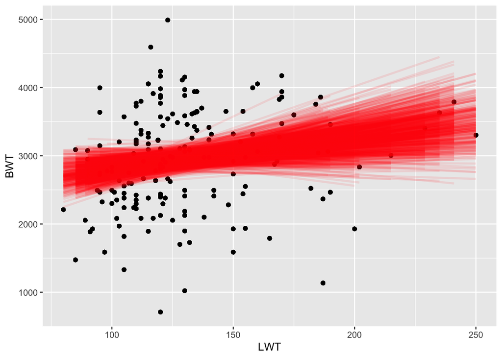

```r
ggplot(result.tbl) +
  geom_point(aes(x = LWT, y = BWT), alpha = 0.6) +
  geom_line(aes(x = LWT, y = Fitted, group = Subset), linewidth = 1, color = "red", alpha = 0.1)
```

The histogram of the slopes show that in some cases the estimated slope is negative, even if the majority are positive. The p-value is not computed directly from this distribution, see the lectures. This distribution is closer linked to the confidence interval for the slope. Since we have 1000 estimates here, if you discard the 25 most extreme estimates in each side of the histogram, the remaining width of the histogram is a rough estimate for the 95% confidence interval!

The histogram of the slopes actually shows the same slope value 50 times, since we stored the slope in each of the 50 rows in the `res.tbl`. To select only one from each subset, we could run

```r
result.tbl %>%
  group_by(Subset) %>%
  slice(1) %>%
  ggplot() +
  geom_histogram(aes(x = slope), bins = 50)
```

However, this will not change the shape of the histogram, just make all values on the y-axis smaller (50 times).

The figure showing the “cloud” of regression lines, one for each of the 1000 subsets, is an image you should always remember when you see a single regression line in a plot. The single line is always a random sample of many such lines! The spread between the lines depend on

- How many data cases we have
- How well the model fits the data
- How presicely the data have been collected

To see some effect of the sample size, try to run the simulations again, but reduce the subsets to 25 data cases, or even smaller, and the “cloud” of regression lines get wider.

# 4 Advertising data

A data set contains sales-numbers of a certain product in 200 markets. In addition there are advertising budgets (in thousand dollars) for each case of TV, radio and newspapers. The question is how large the effect of advertising is on sales. The data are also used in the book “An introduction to statistical learning” which may be found in the curriculum file on CANVAS.

Download the file «Advertising.Rdata» to your computer from the course pages on CANVAS (data module) and load the data into R Studio. Click on the data set listed in the environment window to have a look at the data after it has been loaded.

## 4.1 Summary statistics

Compute the sample means, the sample standard deviations, and percentiles for all four variables. You may use the skim-function in the skimr-library for this purpose. Which channel for advertising, TV, Radio or Newspaper has on average the largest budgets? In which channel does the advertising costs vary the most?

```r
skim(Advertising,Newspaper,Radio,Sales)
```

**Solution**

Data summary

| Name | Advertising |
| --- | --- |
| Number of rows | 200 |
| Number of columns | 4 |
| _______________________ |  |
| Column type frequency: |  |
| numeric | 3 |
| ________________________ |  |
| Group variables | None |

**Variable type: numeric**

| skim_variable | n_missing | complete_rate | mean | sd | p0 | p25 | p50 | p75 | p100 | hist |
| --- | --- | --- | --- | --- | --- | --- | --- | --- | --- | --- |
| Newspaper | 0 | 1 | 30.55 | 21.78 | 0.3 | 12.75 | 25.75 | 45.10 | 114.0 | ▇▆▃▁▁ |
| Radio | 0 | 1 | 23.26 | 14.85 | 0.0 | 9.97 | 22.90 | 36.52 | 49.6 | ▇▆▆▆▆ |
| Sales | 0 | 1 | 14.02 | 5.22 | 1.6 | 10.38 | 12.90 | 17.40 | 27.0 | ▁▇▇▅▂ |

## 4.2 Scatterplots

Create a scatterplot-matrix for all variables using the scatterplotMatrix function as shown below. Use the plot to comment on the dependence (or lack thereof) between the following variable pairs:

- Sales and Newspaper
- Sales and Radio
- Sales and TV

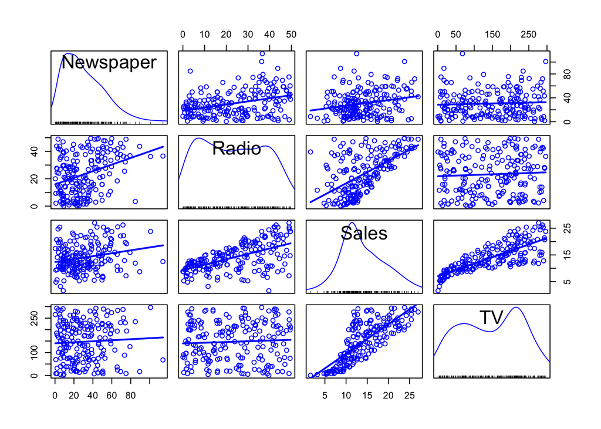

```r
scatterplotMatrix(~Newspaper+Radio+Sales+TV,regLine=TRUE, smooth=FALSE, data=Advertising)
```

**Solution**

From the plots in the row of Sales, we see that the amount of advertisement in newspaper seems to have small effect on the sales. The correlation, if any, is very small and the observations scatter all around with no apparent dependence between the variables. The correlation seems to be positive and higher between sales and radio advertisement. A clear positive trend in sales as radio advertising increases. An even stronger association is found between sales and TV-advertisements. However, the positive effect of TV-advertising is strongest for low advertising budgets. Beyond a certain budget level the effects on sales flattens out.

## 4.3 Model and assumptions

Assume a regression model with sales as response variable and radio as predictor variable. Write up the model with all assumptions.

**Solution**

The model is:

$$y_i = \beta_0 + \beta_1 x_i +
\epsilon_i$$
where $i=1,\ldots,200$ and where $y_i$ and $x_i$ is observation $i$ of sales and radio advertisment, respectively, $\beta_0$ is the constant term (intercept), $\beta_1$ is the regression coefficient and the effect of radio and $\epsilon_i$ is the error term with assumptions
$$\epsilon_i \sim N(0,
\sigma^2)$$
All error terms are assumed independent of each other.

Fit the model in RStudio. From the output locate the three estimated model parameters and interprete them. Also find the determination coeficient $R^2$ and interprete it.

**Solution**

```r
LinearModel.1 <- lm(Sales ~ Radio, data=Advertising)
summary(LinearModel.1)
```

[output not shown]

The least squares estimates of the regression coefficients with interpretations are:

$\hat{\beta}_0 = 9.312$ is the expected sales if no radio advertisment is made.

$\hat{\beta}_1 = 0.203$ is the expected change in sales (in thousand dollars) for a unit’s increase in the radio advertisement budget.

$\hat{\sigma} = s = 4.275$ is the standard deviation of sales for any given and fixed level of radio advertisment.

The $R^2$ is found to be 0.332, which means that about 33.2 % of total the variation in sales numbers can be explained by the linear model with radio as predictor.

## 4.4 Fitted line plot

Make a corresponding fitted line plot. This can be done in many ways in R as we’ve seen earlier by ggplot2, but a simple way using regular plot-function and the abline-function is shown in the code below.

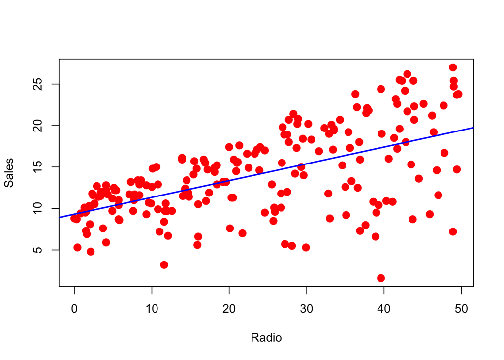

```r
plot(Sales ~ Radio, data=Advertising, pch=20, cex=2, col ="red")
abline(LinearModel.1, col="blue", lwd=2)
```

Do you think the model fits the data well? Do you think the model assumptions as you made in exercise e. are fulfilled?

**Solution**

From the plot there appears to be a linear association between the variables, but the assumption of constant variance for the error term independent of the level of the x-variable is questionable. The spread around the line seems to increase with increasing radio advertisement budget. Furthermore, the spread beneath the line seems to be larger than above the line which also makes the normal distribution of the errors questionable.

## 4.5 Model diagnostics

Create some model diagnostics plots. Do the plots support your findings in the previous exercise?

**Solution**

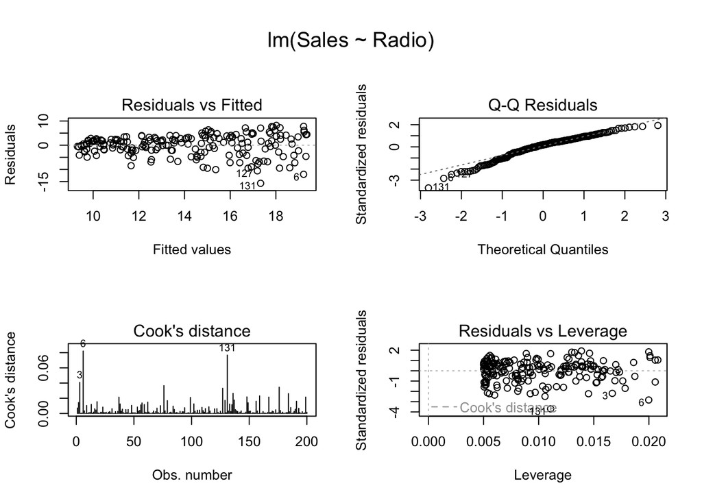

```r
oldpar <- par(oma=c(0,0,3,0), mfrow=c(2,2))
plot(LinearModel.1, which = c(1,2,4,5), add.smooth=FALSE)
```

```r
par(oldpar)
```

Yes, the deviations from the model assumptions are even more clear here. From the top-left plot of fitted-values versus residuals, the increasing variance of the residuals as $\hat{y}$ increases is clearly visible. Also from the normality Q-Q plot (top-right) we can see the slight deviation from the normal distribution with a heavier tail towards negative residuals (the observed redisuals are smaller than what is expected according to a normal distribution).

## 4.6 Other predictor variables

Repeat the previous exercises replacing radio with TV.

**Solution**

```r
LinearModel.2 <- lm(Sales ~ TV, data=Advertising)
summary(LinearModel.2)
```

[output not shown]

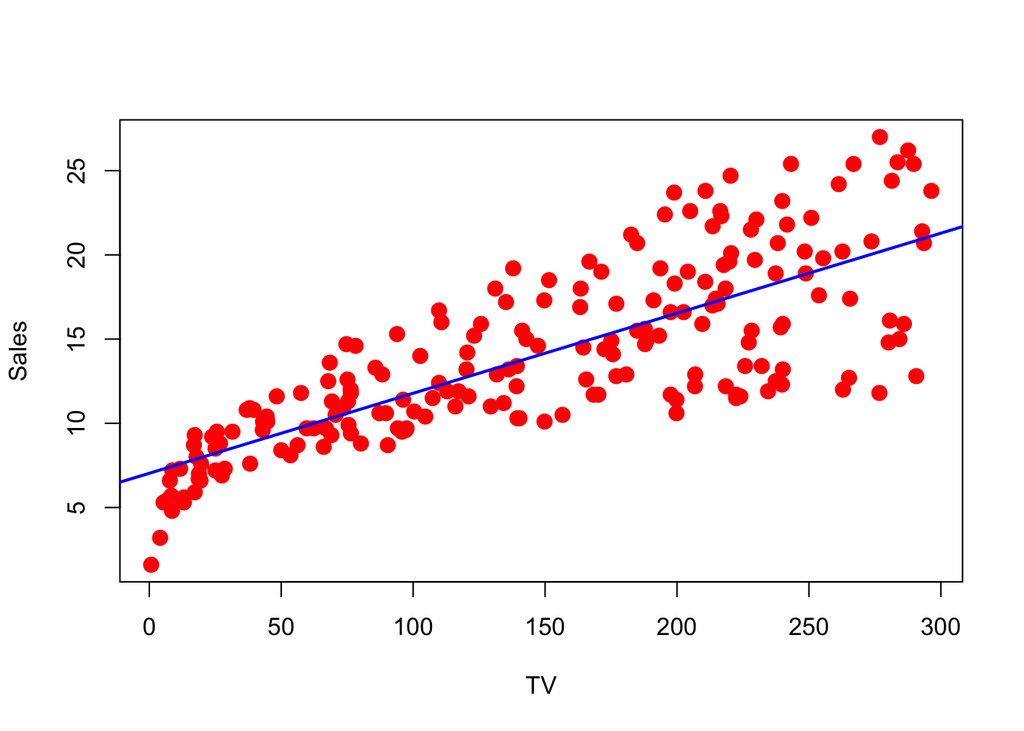

```r
plot(Sales ~ TV, data=Advertising, pch=20, cex=2, col ="red")
abline(LinearModel.2, col="blue", lwd=2)
```

The scatterplot shows a linear relationship between sales and TV for TV-budgets larger than about 50, but across the entire range of TV-budgets the association seems non-linear. The vertical spread around the line is quite even, so the normality assumption may be quite OK, but again, the variability seems to increase with increasing value of x.

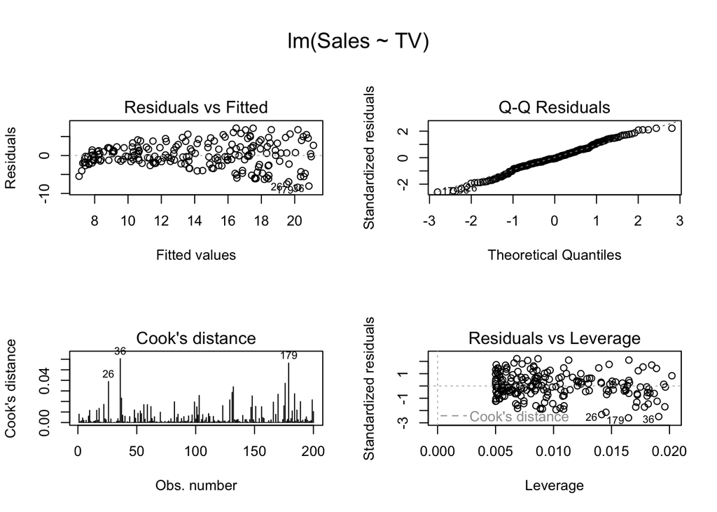

```r
oldpar <- par(oma=c(0,0,3,0), mfrow=c(2,2))
plot(LinearModel.2, which = c(1,2,4,5), add.smooth=FALSE)
```

```r
par(oldpar)
```

The non-liearity of the association between TV-budget and sales is apparent from the banana shaped residual plot. Also the increasing variance is clear. These are clear violations of the model assumptions, even though the normality seems better here.

## 4.7 Transformation of variables

Create a new transformed Sales variable as the natural logarithm of sales and call it logSales. Also make a new logTV variable in the same way. Click on the “view data set”-button afterwards to check that logSales and logTV were added as new variables to your data set. Here is a way to do this in RStudio:

```r
Advertising$logSales <- with(Advertising, log(Sales))
Advertising$logTV <- with(Advertising, log(TV))
```

Fit a new model with logSales as response variable and logTV as predictor. Run the diagnostics plots. Does the fit improve? Are assumptions fulfilled?

**Solution**

[figure not shown]

## 4.8 Hypothesis testing

Now that we have found a reasonable model, perform hypothesis tests at 5% level to test the following hypotheses:

$H_0: \beta_1 = 0$ vs $H_1:\beta_1 \neq 0$

$H_0: \beta_0 = 0$ vs $H_1:\beta_0 \neq 0$

How can we conclude about the effect of logTV on logSales?

**Solution**

$$|T|>t_{\alpha/2, n-p-1}$$
where $t_{\alpha/2, n-p-1}$ is the upper $\alpha/2$ percentile of the t-distribution with $n-p-1$ degrees of freedom. This value can be read from a t-table, and in our case we have $n=200$ and $p=1$, that is 198 degrees of freedom. If we look up in the t-table, the closest degrees of freedom are 100 and 1000. We choose 1000 since this gives a concervative conclusion. We find $t_{\alpha/2, n-p-1}=1.9623$ and reject the null-hypothesis. We could also make the same conclusion by observing that the p-value of the last column in the coefficients table is very small, and smaller than the test level 0.05. We can therefore claim that logTV has a significant and positive effect on logSales.

We can repeat the same procedure to test the second hypothesis. We conclude that the intercept of the model is different from zero.

## 4.9 Confidence intervals

Compute 95% confidence intervals for the regression coefficients as shown in the code here:

```r
Confint(LinearModel.4, level=0.95)
```

How can we interpret these intervals?

**Solution**

```r
Confint(LinearModel.4, level=0.95)
```

```
##              Estimate     2.5 %    97.5 %
## (Intercept) 0.9052455 0.7650955 1.0453954
## logTV       0.3550357 0.3257063 0.3843652
```

It is a 95% probability that the intervals cover the true and unknown value of the regression coefficents.

## 4.10 Optional mathematical exercise

The model which you just fitted to Sales and TV on the original scale is really:
$$y_i = \beta_0\cdot
x_i^{\beta_1}\cdot \epsilon_i$$
which is a so-called multiplicative model. Show that the transformations you made to Sales and TV in exercise i. transforms this model into a linear model. How do the estimated regression coefficients of the model you fitted in i. relate to the $\beta_0$ and the $\beta_1$ in the multiplicative model?

**Solution**

Taking the logarithm on both sides we obtain:

$$\begin{split}
log(y_i) &= log(\beta_0\cdot x_i^{\beta_1}\cdot \epsilon_i))\\
log(y_i) &= log(\beta_0) + log(x_i^{\beta_1}) + \log(\epsilon_i)\\
log(y_i) &= log(\beta_0) + \beta_1log(x_i) + \log(\epsilon_i)\\
y_i^* &= \beta_0^* +\beta_1 x_i^* + \epsilon_i^*
\end{split}$$
where $y_i^*$ is logSales, $x_i^*$ is logTV. We can see that the intercept we estimated in the transformed model ($\hat{\beta}_0^*=0.905$) really is the logarithm of the $\beta_0$ in the multiplicative model. Hence we can find $\hat{\beta}_0 = \exp(\hat{\beta_0^*})=exp(0.905) = 2.47$. The $\beta_1$ is un-transformed, hence $\hat{\beta}_1 = 0.355$. Furthermore, the error terms in the transformed model are the logarithms of the error terms of the multiplicative model.

To verify this we can add the estimated multiplicative model to a scatterplot of Sales and TV-budget, as in this code:

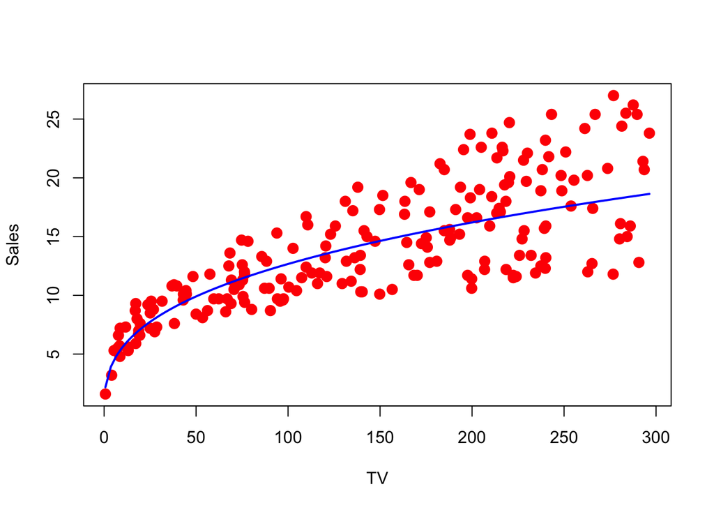

```r
plot(Sales~TV, pch=20, cex=2, col="red", data=Advertising)
curve(2.47*x^(0.355), add=TRUE, lwd=2, col="blue")
```